# We Rate Dog Dataset analysis report

The WeRateDogs twitter account from where the data was sourced from has a unique rating system. The denominator is uasually 10 whereas the numberator could be greater than 10. The rating system is a standard/unique aspect of the dataset hence I did not clean the two columns. Udacity provided the data used in this analysis and also ran the images on WeRateDogs's account through a neural network to generate three predictions for each image. I wrangled the data for original content with images.

After wrangling of we rate dogs dataset, analysis of the merged dataframes reveals a total of 1477 original tweets. The data analysed was from tweets starting from 2015-11-15 to 2017-08-01.

The most liked breed is Afghan_hound with a mean favorite count of 17326.66666 and Border_terrier with mean favorite count of (13578.000000). There are 111 special breeds. golden_retriever (139) and Labrador_retriever (95) had the most tweet rate whereas standard_schnauzer (1) and clumber have the least tweet rates. In addition to these; i analysed the following

1. WeRateDogs's posting trend by month?

Since the account was created, there is an obvious decline in the number of posts made on WeRateDog account, went from about 250 tweets in one month down to less 50 in the latest months. There was a sharp downward trend only a few months after the account was created. My analysis focused on only original tweets with image, therefore the decline could be attributed to changes in the accounts area of content such as use of videos,retweets etc and not necessarily decrease in overall post.

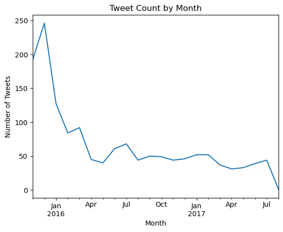

# monthly trend of interactions on WeRateDogs's posts

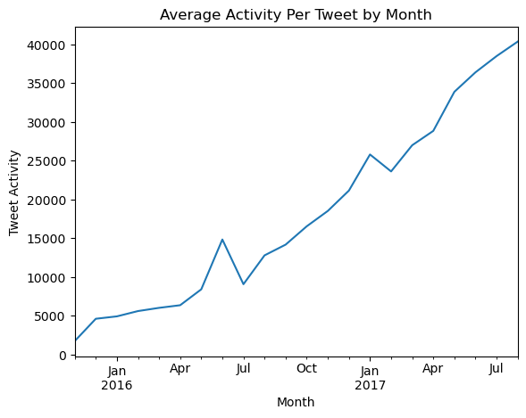

Four distinct dog stages were identified with some tweet_id's having more than one stage. Dogggo,Puppo has the highest retwet counts and pupper is the least retweeted dog stage.

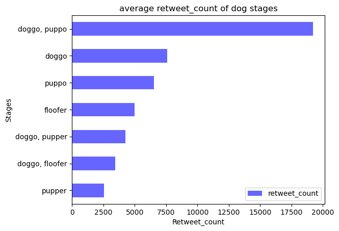